# Chapter 5

The probability of a binary event $Pr(y_i=1) = p_i$ needs to be mapped onto a 0-1 range. You do that with the logit function. The logit funciton maps from 0:1 to $-\infty$ to + $\infty$: $logit(x) = log \frac{x}{1-x}$

$logit(p_i) = X_i \beta$

so that’s

$Pr(y_i=1) = logit^{-1}(X_i ) $

So you need it’s inverse $logit^{-1}(x) = \frac{e^x}{1+e^x}$

```
## glm(formula = vote ~ income, family = binomial(link = "logit"))
##             coef.est coef.se
## (Intercept) -1.40     0.19
## income       0.33     0.06
## ---
##   n = 1179, k = 2
##   residual deviance = 1556.9, null deviance = 1591.2 (difference = 34.3)
```

So here we’ve got the probability of Bush’s support at the average respondednts income:

```r
invlogit(coef(fit.1)[1] + coef(fit.1)[2]*mean(income, na.rm = TRUE))
```

```
## (Intercept)
##   0.4014235
```

So for respondents with an income level of 3.07, the probability of voting for Bush is 0.40. The difference of one in income corresoinds to a .33 increase in the logit probability of Bush’s support:

$logit^{-1}(-1.40+0.33*3) - logit^{-1}(-1.40+0.33*2)$ = 0.0747344

So that’s an increase of 7.4 %.

There’s a divide by 4 rule: if you take the coefficient and divide it by 4 it gives you the upper bound of an increase corresponding to 1 unit increase in the predictor - this happens at the .5 probability.

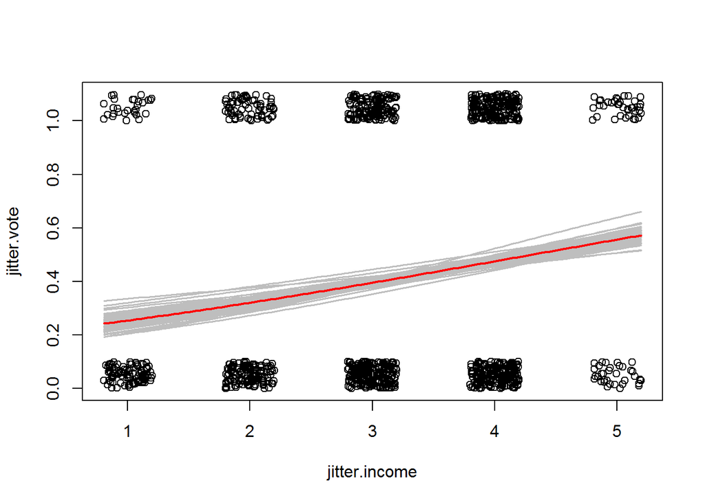

### Fitting and displaying the model

So here’s the data for all the years and you can see that income has always been predicitive of republican voting intention, but has gotten stronger over the years.

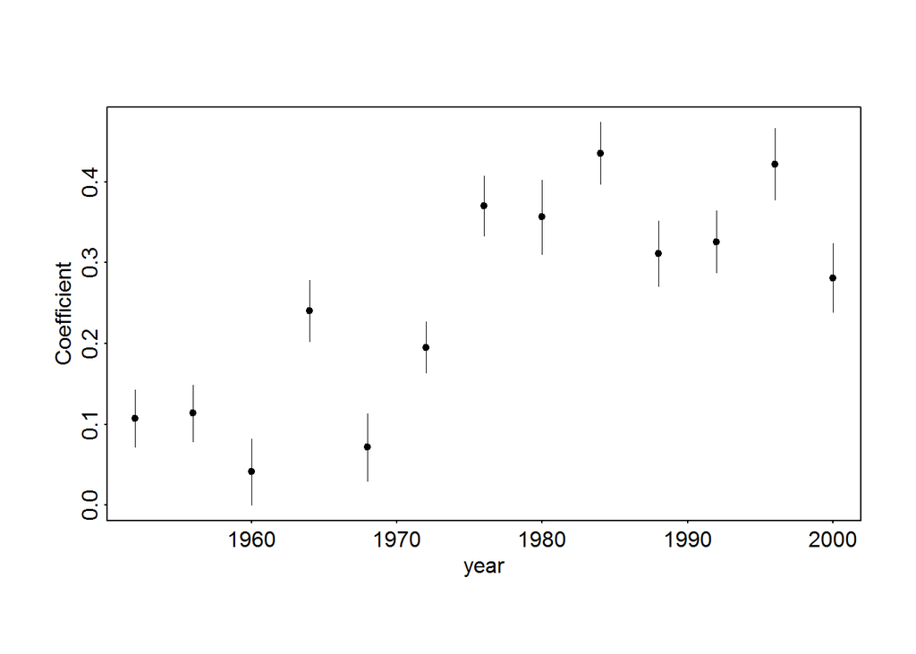

```r
coefs <- array(NA, c(24,3))

for (i in 1:length(unique(nes.year))){
  ok <- nes.year==unique(nes.year)[i] & presvote<3
  sum(ok, na.rm = TRUE)
  vote <- presvote[ok] - 1
  income <- data$income[ok]
 if(sum(ok, na.rm = TRUE) > 0) {
     fit <- glm(vote ~ income, family = binomial(link = "logit"))
  coefs[i,] <- c(unique(nes.year)[i], coef(summary(fit))[2,1:2])}
}

coefs <- coefs[complete.cases(coefs),]

  plot (range(coefs[,1]), range(0,coefs[,2]+.67*coefs[,3],coefs[,2]-.67*coefs[,3]),
     type="n", xlab="year", ylab="Coefficient", mgp=c(1.2,.2,0), cex.main=1,
      cex.axis=1, cex.lab=1, tcl=-.1)

  points (coefs[,1],coefs[,2], pch=20)
  segments (coefs[,1], coefs[,2]+.67*coefs[,3], coefs[,1], coefs[,2]-.67*coefs[,3], lwd=.5)
```

## Latent data fromulation

Logistic regression interpretation:

- direct: as a nonlinear model for the probabilty of a success given some predictors
- indiredct: using latent variables:

$y_i = \begin{cases} 1 & \quad if z_i >0 \\ o & \quad if z_i < 0 \\ \end{cases}$ $z_i = X_i \beta + \varepsilon_i$

with independent errors $\varepsilon_i$ that have a logistic probability distribution.

The **logistic probability distribution** is defined as

$Pr(\varepsilon_i < x) = logit ^{-1}(x)\quad for \quad all \quad x$

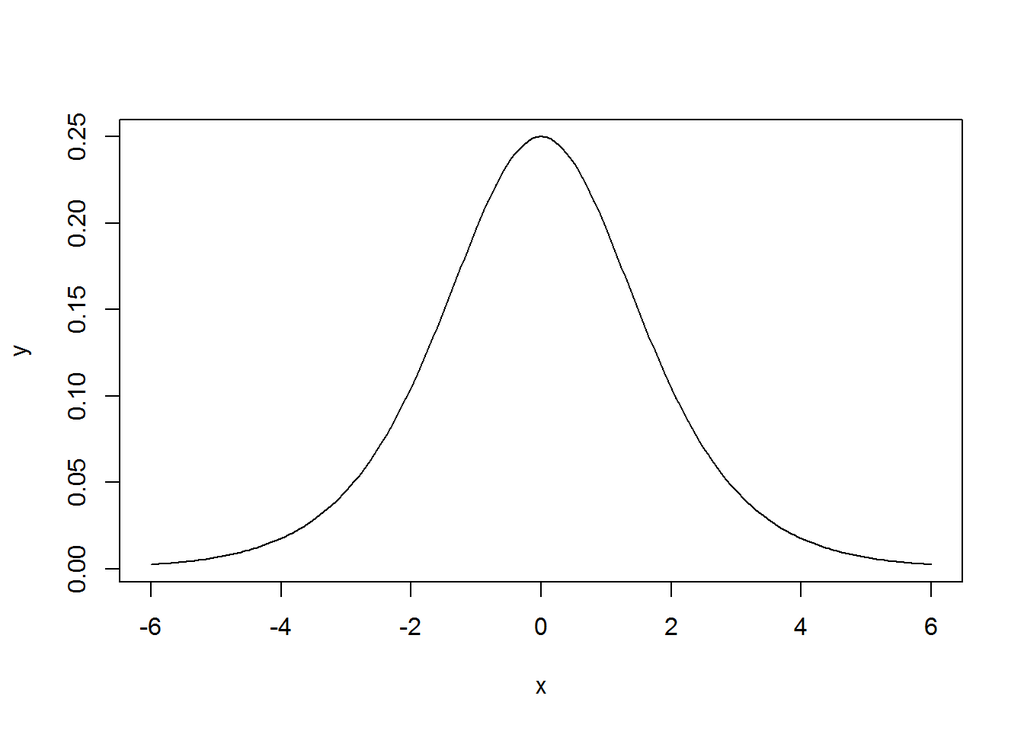

So the same as the first equation above: $Pr(y_i=1)$ is the same as $Pr(z_i>0)$ and that’s the same as the error being larger than the linear term $P(X_i \beta - \varepsilon_i < 0)$ which is the inverse logit $logit ^{-1}(X_i \beta)$

So here’s what it looks like graphically: - remember, the formula was $logit^{-1}(-1.40+0.33*x_i)$, so a person with income 1, for them the linear predictor is $-1.40 + 0.33 = -1.07$. The curve in the figure is the distribution of the latent variable $z_i$: because it’s value is -1.07 + the error. So and the shaded area is the probability of $z_i$ is more than zero, which is the same as saying the probability that $y_i = 1$. In this example it is $logit^{-1}(-1.07)=$ 0.2554031

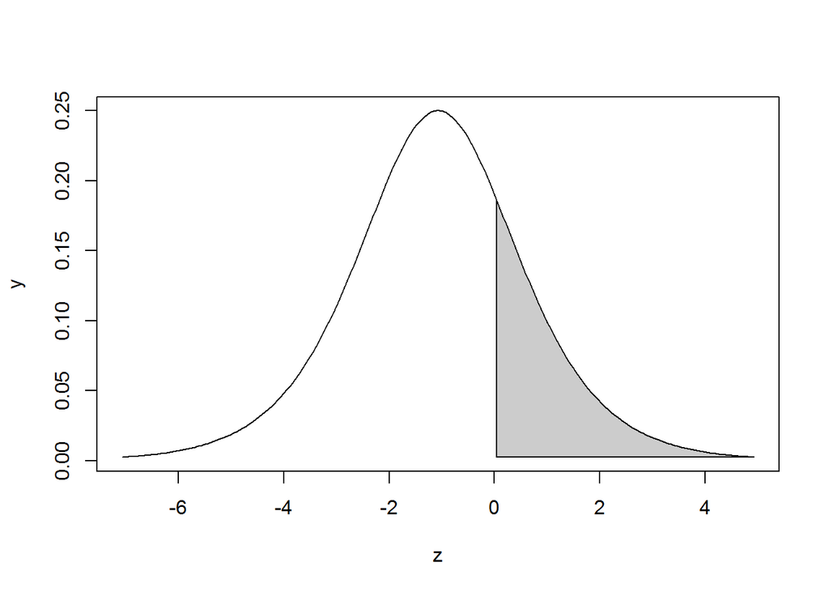

Fig: Latent variable formulation of logit

This is a computational trick, but can also be interpreted substantively: in the survey y=1 for Bush supporters and y=0 for Clinton supporters. The “unobserved continuous variable $z_i$ can be interpreted as the respondent’s utility or preference for Bush relative to Clinton - the sign tells you which candidate is preferred and the magniture the strenght of preference.”

The logistic density function is very close to a normal with sd = about 1.6, the unit of the logistic distribution. The error of the model can not be modelled using a normal though, because you cannot determine the sd parameter. Therefore you model it with a logistic distribution, where you don’t have to determine any parameters.

## Builiding a logistic regression model: wells in Bangladesh

```
## glm(formula = switch ~ dist100, family = binomial(link = "logit"))
##             coef.est coef.se
## (Intercept)  0.61     0.06
## dist100     -0.62     0.10
## ---
##   n = 3020, k = 2
##   residual deviance = 4076.2, null deviance = 4118.1 (difference = 41.9)
```

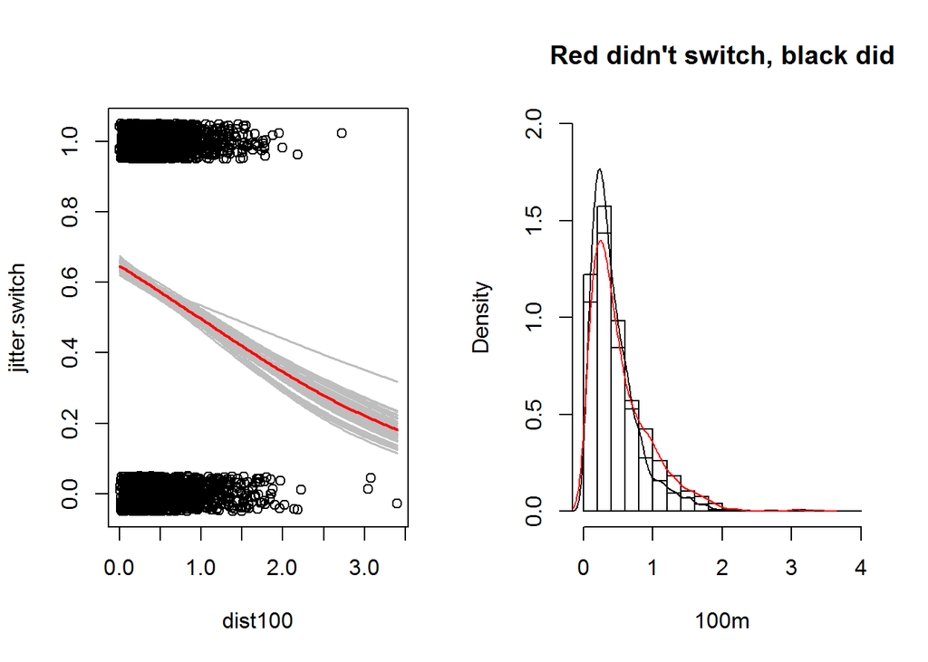

So the chart on the left shows the probability of switching is over 60% if you live next to a safe well, and it declines to about 20% if you are more than 300 metres away.

### Coefficient interpretation:

$Pr(switch = 1) = logit^{-1}(0.61 -0.62 \times distance100)$

So the constant term is interpreted at distance = 0, so $logit^{-1}(0.61) =$ 0.6470185, so about 64% percent.

The average distance in the dataset $\bar{dist100}=$ 0.4833186, that’s 48 meters, let’s see the derivative at that value:

- The value of the linear predictor at the average distance is then $0.61 - 0.62*0.48 =$ 0.3124
- So then the slope at that point is $-0.62 \times e^{0.31}/ (1+e^{0.31})^2 =$ -0.151335
- so adding 1 (100 meters) to the distance of the nearest safe well corresponds to the probability of switching falling by about 15 percentage points - we would have gotten the same result with the divide by 4 rule

### Adding another independent (input) variable

```
## glm(formula = switch ~ dist100 + arsenic, family = binomial(link = "logit"))
##             coef.est coef.se
## (Intercept)  0.00     0.08
## dist100     -0.90     0.10
## arsenic      0.46     0.04
## ---
##   n = 3020, k = 3
##   residual deviance = 3930.7, null deviance = 4118.1 (difference = 187.4)
```

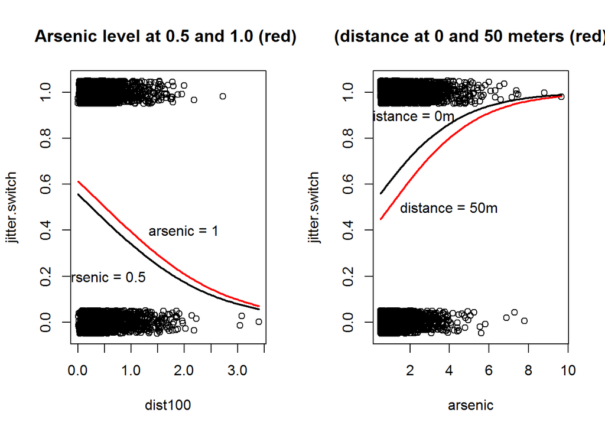

So interpretation:

- For two wells with the same arsenic level, an increse in the distance of a safe well by 100 meters, corresponds to the logit probability of switching falling by 0.90. - divide by 4 rule: 22.5 percent lower probability of swithcing.
- Increasing the arsenic level by one - at the same distance, increases probability of switching by about 11 percent.
- You’d think distance is more important than arsenic levels based on this, but you have to see it relative to the variation of the input vairables $sd(dist100) =$ 0.3847867 and $sd(arsenic) =$ 1.107387. So the correct comparison is the coefficient that corresponds to one standard deviation, so $-0.90*0.38 = -0.34$ for distance and $0.46* 1.1 = 0.51$ for arsenic. So the coefficient is larger for arsenic - relative to it’s variation. A 1 standard deviation difference in arsenic corresponds to 13% increased probability, and a one std.dev. difference in distance is an 8% reduced probability.

And look, the coefficient for distance went from -0.6 to -0.9 now that we’ve added arsenic to the model. This is because wells that are high in arsenic are also likely to be far from a safe well.